# jonson

## Kütüphaneler

```r
library(tidytext)
library(dplyr)
library(tidyverse)
library(gutenbergr) # Eserleri içerir
library(tidyr)  # Düzenli veri oluşturma
library(stopwords) # İstenmeyen kelimeleri çıkartma
library(ggplot2)  # Görselleştirme
library(wordcloud) # Kelime Bulutu
library(igraph)  # Ağları analiz etme
library(ggraph) # Katmanlı ağ görselleştirmesi
library(reshape2) # Matris dönüşümü
```

Gerekli kütüphaneleri indirdik.

```r
epicoene <- gutenberg_download((4011), meta_fields = "title")
```

Gutenberg kütüphanesinden analizini yapmak üzere 4011 kitap numarasına sahip Ben Jonson’un Epicoene Sessiz Kadınlar adlı eserini indiriyoruz.

## Duraklama Kelimeleri

```r
mystopwords <- tibble(word = c("ı","la","ıt","ın","thou","ı'll","ay","thy"))
```

```r
tidy_epicoene <- epicoene %>%
  unnest_tokens(word, text) %>%
   anti_join(stop_words) %>%
   anti_join(mystopwords)
```

İlk olarak unnest_tokens ile eseri yani verimizi, her satırda tek bir kelime olacak şekilde böldük.Sonrasında ise stop_words ile duraklama kelimeleri olarak adlandırılan the,of,to gibi kelimeleri eledik. Ancak bu işlem, tüm duraklama kelimelerini elemek için yeterli olmadı.Bu sebeple kendi duraklama kelimelerimizi mystopwords şeklinde oluşturarak eserden eledik.

## En Çok Kullanılan Kelimeler

```r
tidy_epicoene %>%
  count(word, sort = TRUE)
```

```
## # A tibble: 8,559 x 2
##    word       n
##    <chr>  <int>
##  1 sir      421
##  2 true     323
##  3 cler     225
##  4 daw      185
##  5 mor      160
##  6 daup     159
##  7 jonson   138
##  8 ott      124
##  9 master    82
## 10 time      76
## # ... with 8,549 more rows
```

En çok kullanılan kelimeleri, kelime sıklığına göre sırasıyla görmekteyiz.İlk 20 kelimeyi inceleyelim.

## Kelime Kullanılma Sıklığı Histogram

```r
tidy <- epicoene %>%
  unnest_tokens(word,text) %>%
  count(word,sort=T) %>%
  anti_join(stop_words) %>%
  anti_join(mystopwords) %>%
  filter(!word %in% stop_words$word,

         str_detect(word, "[a-z]"))
```

[figure not shown]

```r
tidy %>%
  head(20)%>%
  ggplot(aes(reorder(word,n),n))+
  geom_col(fill= "purple")+
  coord_flip()+
  labs(x="kelimeler",
       y="Kelime Sayısı",
       title= "The Merchant of Venice")
```

En çok kullanılan ilk 20 kelimeye baktığımızda mor,daup,john,daw,hau,epi,ott gibi kelimelerin eserdeki karakterler olduğunu söyleyebiliriz.Kelimeleri daha geniş çaplı incelediğimizde mor’un Morose kişisini, daup’un Dauphine kişisini ve diğer kişilerin isimlerinin de en sık kullanılan kelimelerde kısaltılmış hallerini temsil ettiğini görebilmekteyiz.Daw, şafak anlamına gelirken bunun bir karakter olduğunu anlamak için geniş çaplı bir analiz şarttır.Bunun dışında sir, master gibi kelimelerin de sık kullanıldığını görüyoruz.Bu da bize kahramanlar arası bir hiyerarşi olduğunu gösterir.Ayrıca lady,ladies,gentlemen gibi kelimelerden de kelime sıklık sıralamasına göre eserde kadınların ön planda olduğunu söyleyebiliriz.

## Nrc

```r
tidy %>%
  inner_join(get_sentiments("nrc"))
```

```
## # A tibble: 3,909 x 3
##    word         n sentiment
##    <chr>    <int> <chr>
##  1 sir        421 positive
##  2 sir        421 trust
##  3 true       323 joy
##  4 true       323 positive
##  5 true       323 trust
##  6 master      82 positive
##  7 time        76 anticipation
##  8 john        58 disgust
##  9 john        58 negative
## 10 mistress    52 anger
## # ... with 3,899 more rows
```

Metindeki düşünce veya duyguyu değerlendirmek için var olan çeşitli yöntemler ve sözlükler vardır. Bu sözlüklerden biri olan nrc, duyguyu olumlu,olumsuz,sevinç,üzüntü,öfke vb şekilde ayırarak numaralandırır.

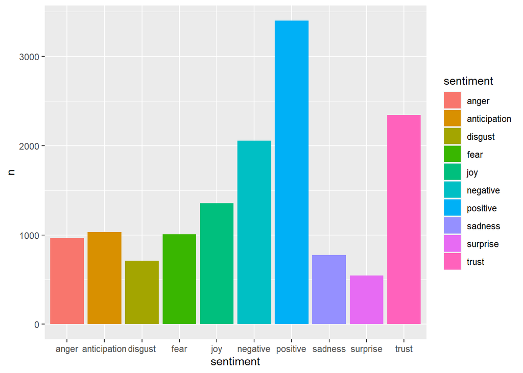

```r
tidy %>%
  inner_join(get_sentiments("nrc")) %>%
  ggplot(aes(sentiment, n, fill= sentiment))+
  geom_col()
```

Grafiğe baktığımızda, esere genel olarak pozitif bir duygunun hakim olduğunu görmekteyiz.Karşılıklı güvenilir ilişkiler de söz konusudur. Bunun yanı sıra öfke,beklenti,iğrenme,korku,üzüntü,sevinç gibi duygular da eserde yerini almıştır.Duyguların çoğunluğu negatif olmasına karşın bu sözlükte pozitif bir sonuç elde ettik.Şimdi bir de bing sözlüğünü inceleyelim.

## AFİNN

```r
AFINN <- get_sentiments("afinn")
AFINN
```

```
## # A tibble: 2,477 x 2
##    word       value
##    <chr>      <dbl>
##  1 abandon       -2
##  2 abandoned     -2
##  3 abandons      -2
##  4 abducted      -2
##  5 abduction     -2
##  6 abductions    -2
##  7 abhor         -3
##  8 abhorred      -3
##  9 abhorrent     -3
## 10 abhors        -3
## # ... with 2,467 more rows
```

## Bing

```r
tidy %>%
  inner_join(get_sentiments("bing"))
```

```
## # A tibble: 1,244 x 3
##    word          n sentiment
##    <chr>     <int> <chr>
##  1 master       82 positive
##  2 mistress     52 negative
##  3 humour       44 positive
##  4 love         43 positive
##  5 faith        34 positive
##  6 fair         27 positive
##  7 gold         21 positive
##  8 noise        21 negative
##  9 excellent    20 positive
## 10 worth        20 positive
## # ... with 1,234 more rows
```

Bing sözlüğünde ise analizin, duyguları pozitif ve negatif şekilde ayırmaya yönelik yapıldığını görüyoruz.

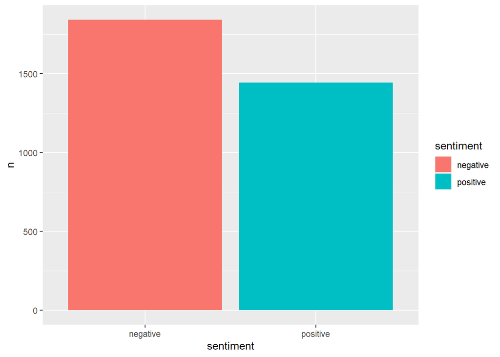

```r
tidy %>%
  inner_join(get_sentiments("bing")) %>%
  ggplot(aes(sentiment, n, fill= sentiment))+
  geom_col()
```

Grafiğe baktığımızda bu analizde nrc sözlüğünün aksine eserde negatif bir duygu yoğunluğunun olduğunu net bir şekilde görmekteyiz.

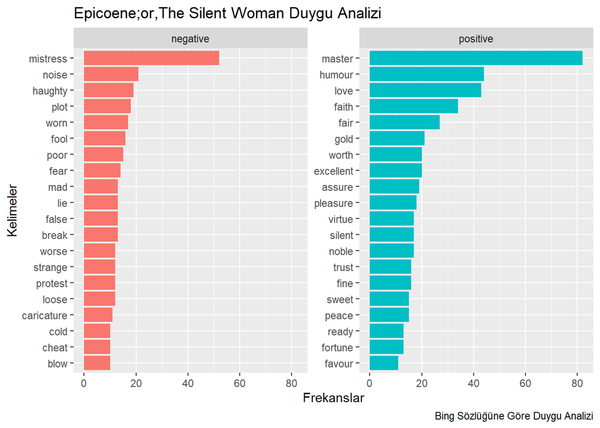

```r
rbind(

tidy %>%
  inner_join(get_sentiments("bing")) %>%
  arrange(-n) %>%
  filter(sentiment == "positive") %>%
  head(20),

tidy %>%
  inner_join(get_sentiments("bing")) %>%
  arrange(-n) %>%
  filter(sentiment == "negative") %>%
  head(20)) %>%
  ggplot(aes(reorder(word,n),n, fill=sentiment)) +
  geom_col(show.legend = FALSE)+
  facet_wrap(~sentiment,scales = "free_y") +
  coord_flip() +
  labs( x = "Kelimeler" , y = "Frekanslar" , title = "Epicoene;or,The Silent Woman Duygu Analizi" , caption = "Bing Sözlüğüne Göre Duygu Analizi" )
```

Bing sözlüğüne göre negatif ve pozitif duyguları detaylı incelediğimizde negatif duygularda ilk sıralarda arsa,yıpranmış kelimelerini görürken sonlara doğru protesto,hile,darbe gibi kelimeleri görmekteyiz.Bu kelimelerden; eserde arsa, miras sorunları olduğunu ve bu sorunların hile,darbe gibi kelimelerden yola çıkarak yakın çevre arası sorun ve çeşitli kötü oyunlara sebebiyet verdiğini söyleyebiliriz.Pozitif duygulara baktığımızda da altın,güven,servet,değer gibi kelimelerden de bu olayın izlerini görmekteyiz.Şimdi nrc sözlüğünü öfke kelimeleri için kullanalım.

```r
nrc_anger <- get_sentiments("nrc") %>%
  filter(sentiment == "anger")

tidy_epicoene %>%
  inner_join(nrc_anger) %>%
  count(word, sort = TRUE)
```

```
## # A tibble: 344 x 2
##    word         n
##    <chr>    <int>
##  1 mistress    52
##  2 court       46
##  3 bear        36
##  4 money       20
##  5 haughty     19
##  6 fear        14
##  7 disease     13
##  8 lie         13
##  9 mad         13
## 10 words       12
## # ... with 334 more rows
```

## Kelime Bulutu

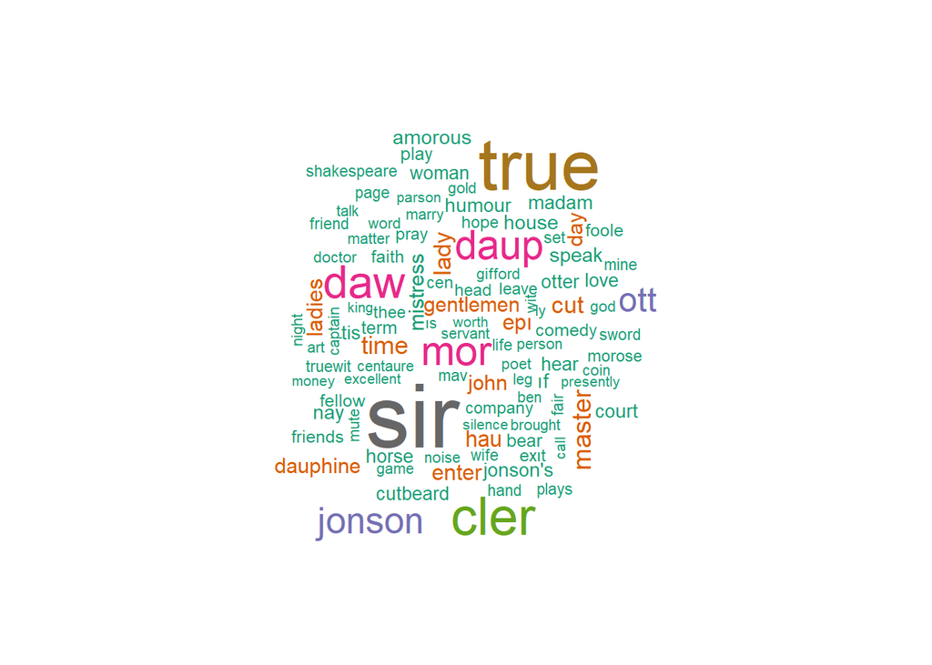

```r
tidy_epicoene %>%
  anti_join(stop_words) %>%
  count(word) %>%
  with(wordcloud(word, n, max.words = 100,colors=brewer.pal(8, "Dark2")))
```

Kelime bulutuna baktığımızda ise kelimelerin kullanım sıklığına göre boyutlarının değiştiğini görmekteyiz.İlk 100 kelimeye baktığımızda karakterlerin isimlerine dair kısaltmaları ve orjinallerini daha net görüyoruz.Bunun dışında bir evlilik ve ayrılığın olduğunu, dua etme,inanç kelimelerinden bir inanış söz konusu olduğunu söyleyebiliriz.

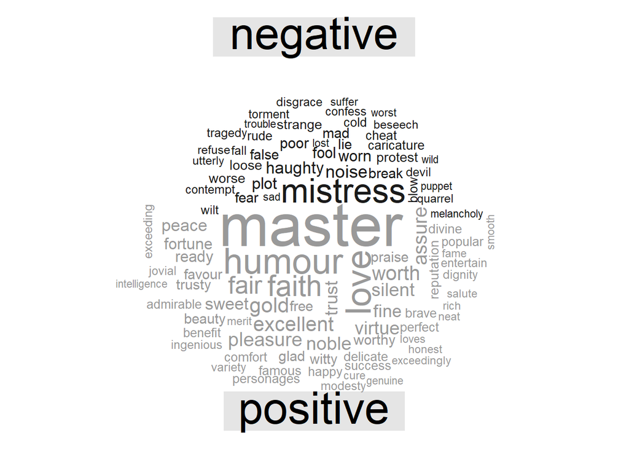

```r
tidy_epicoene %>%
  inner_join(get_sentiments("bing")) %>%
  count(word, sentiment, sort = TRUE) %>%
  acast(word ~ sentiment, value.var = "n", fill = 0) %>%
  comparison.cloud(colors = c("gray10", "gray60"),
                   max.words = 100)
```

comporison.cloud fonksiyonu ile belgelerdeki sözcüklerin sıklığını karşılaştıran bir bulut oluşturduk.acast fonksiyonu ise bir veri çerçevesi oluşturmamıza yardımcı oldu.Gafikte ise kelime boyutu arttıkça kullanım sıklığının arttığını, renk tonu arttıkça ise negatif duygu durumunun arttığını söyleyebiliriz.

```r
bingnegative <- get_sentiments("bing") %>%
  filter(sentiment == "negative")

wordcounts <- tidy_epicoene %>%
  group_by(title, gutenberg_id) %>%
  summarize(words = n())

tidy_epicoene %>%
  semi_join(bingnegative) %>%
  group_by(title, gutenberg_id) %>%
  summarize(negativewords = n()) %>%
  left_join(wordcounts, by = c("title", "gutenberg_id")) %>%
  mutate(ratio = negativewords/words) %>%
  filter(gutenberg_id != 0) %>%
  slice_max(ratio, n = 1) %>%
  ungroup()
```

```
## # A tibble: 1 x 5
##   title                          gutenberg_id negativewords words  ratio
##   <chr>                                 <int>         <int> <int>  <dbl>
## 1 Epicoene; Or, The Silent Woman         4011          1842 22196 0.0830
```

### İlk olarak bing sözlüğüne göre negatif kelimeleri filtreledik.Sonrasında bölümlerin uzunluklarını normalleştirebilmemiz için her bölümde kaç kelime olduğuna dair wordcounts adında bir veri çerçevesi elde ettik.Son olarak ise her bölümdeki olumsuz kelime sayısının toplam kelimelere oranını elde ettik.Bu oran 0.08 oldu.Aynı işlemi pozitif kelimeler için de yapalım.

```r
bingpositive <- get_sentiments("bing") %>%
  filter(sentiment == "positive")

wordcounts <- tidy_epicoene %>%
  group_by(title, gutenberg_id) %>%
  summarize(words = n())

tidy_epicoene %>%
  semi_join(bingpositive) %>%
  group_by(title, gutenberg_id) %>%
  summarize(positivewords = n()) %>%
  left_join(wordcounts, by = c("title", "gutenberg_id")) %>%
  mutate(ratio = positivewords/words) %>%
  filter(gutenberg_id != 0) %>%
  slice_max(ratio, n = 1) %>%
  ungroup()
```

```
## # A tibble: 1 x 5
##   title                          gutenberg_id positivewords words  ratio
##   <chr>                                 <int>         <int> <int>  <dbl>
## 1 Epicoene; Or, The Silent Woman         4011          1444 22196 0.0651
```

Aynı işlemi pozitif kelimelerde uyguladığımızda oranın 0.06 olduğunu görüyoruz.Buradan da negatif duygunun baskın olduğu sonucuna ulaşıyoruz.

## NGRAMLAR (n=2)

```r
epicoene_bigrams <- epicoene %>%
  unnest_tokens(bigram, text, token = "ngrams", n = 2)
epicoene_bigrams
```

```
## # A tibble: 47,383 x 3
##    gutenberg_id title                          bigram
##           <int> <chr>                          <chr>
##  1         4011 Epicoene; Or, The Silent Woman epıcoene or
##  2         4011 Epicoene; Or, The Silent Woman or the
##  3         4011 Epicoene; Or, The Silent Woman the sılent
##  4         4011 Epicoene; Or, The Silent Woman sılent woman
##  5         4011 Epicoene; Or, The Silent Woman <NA>
##  6         4011 Epicoene; Or, The Silent Woman <NA>
##  7         4011 Epicoene; Or, The Silent Woman by ben
##  8         4011 Epicoene; Or, The Silent Woman ben jonson
##  9         4011 Epicoene; Or, The Silent Woman <NA>
## 10         4011 Epicoene; Or, The Silent Woman <NA>
## # ... with 47,373 more rows
```

n-gram ile n sayıda ardışık sözcük dizinini bir araya getiririz. X kelimesinin ardından Y kelimesinin ne sıklıkla geldiğini görerek, aralarındaki ilişkilerin bir modelini oluşturabiliriz. n=2 aldığımız bu durum bigram olarak adlandırılır.

```r
epicoene_bigrams %>%
  count(bigram, sort = TRUE)
```

```
## # A tibble: 29,474 x 2
##    bigram      n
##    <chr>   <int>
##  1 <NA>     3636
##  2 of the    214
##  3 in the    169
##  4 to the    122
##  5 la f      100
##  6 of a       81
##  7 to be      78
##  8 ı will     71
##  9 ı have     67
## 10 for the    58
## # ... with 29,464 more rows
```

Bir araya gelme sıklıklarına göre kelimeleri ikişerli şekilde sıraladığımızda duraklama kelimelerini ön planda görmekteyiz.Bu kelimelerden kurtulmak için öncelikle kelime gruplarını 2 sütuna ayırmalıyız.

```r
bigrams_separated <- epicoene_bigrams %>%
  separate(bigram, c("word1", "word2"), sep = " ")

bigrams_filtered <- bigrams_separated %>%
  filter(!word1 %in% stop_words$word) %>%
  filter(!word2 %in% stop_words$word) %>%
  filter(!word1 %in% mystopwords$word) %>%
  filter(!word2 %in% mystopwords$word)

# new bigram counts:
bigram_counts <- bigrams_filtered %>%
  count(word1, word2, sort = TRUE)

bigram_counts
```

```
## # A tibble: 6,374 x 3
##    word1  word2        n
##    <chr>  <chr>    <int>
##  1 <NA>   <NA>      3636
##  2 sir    john        46
##  3 sir    amorous     37
##  4 sir    dauphine    28
##  5 john   daw         19
##  6 ben    jonson      18
##  7 master truewit     16
##  8 jack   daw         14
##  9 true   nay         14
## 10 master doctor      13
## # ... with 6,364 more rows
```

seperate, sütunları bir sınırlayıcıya göre birden çok bölüme ayıran bir tidyr fonksiyonudur.Bu fonksiyon ile sütunları ayırdıktan sonra durdurma kelimelerini filter ile eledik.Bu eserde karakterlerin en yaygın çitfler olduğunu söyleyebiliriz.

```r
bigrams_united <- bigrams_filtered %>%
  unite(bigram, word1, word2, sep = " ")

bigrams_united
```

```
## # A tibble: 10,714 x 3
##    gutenberg_id title                          bigram
##           <int> <chr>                          <chr>
##  1         4011 Epicoene; Or, The Silent Woman sılent woman
##  2         4011 Epicoene; Or, The Silent Woman NA NA
##  3         4011 Epicoene; Or, The Silent Woman NA NA
##  4         4011 Epicoene; Or, The Silent Woman ben jonson
##  5         4011 Epicoene; Or, The Silent Woman NA NA
##  6         4011 Epicoene; Or, The Silent Woman NA NA
##  7         4011 Epicoene; Or, The Silent Woman NA NA
##  8         4011 Epicoene; Or, The Silent Woman NA NA
##  9         4011 Epicoene; Or, The Silent Woman NA NA
## 10         4011 Epicoene; Or, The Silent Woman NA NA
## # ... with 10,704 more rows
```

unite fonksiyonu, seperatenin tam tersi işlevde olup ayrı olan kelime sütunlarını tekrar birleştirebilmemizi sağlar.

## (n=3)

```r
epicoene %>%
  unnest_tokens(trigram, text, token = "ngrams", n = 3) %>%
  separate(trigram, c("word1", "word2", "word3"), sep = " ") %>%
  filter(!word1 %in% stop_words$word,
         !word2 %in% stop_words$word,
         !word3 %in% stop_words$word,
         !word1 %in% mystopwords$word,
         !word2 %in% mystopwords$word,
         !word3 %in% mystopwords$word) %>%
  count(word1, word2, word3, sort = TRUE)
```

```
## # A tibble: 2,176 x 4
##    word1    word2    word3        n
##    <chr>    <chr>    <chr>    <int>
##  1 <NA>     <NA>     <NA>      4253
##  2 sir      john     daw         15
##  3 gold     coin     worth        5
##  4 haughty  centaure mavıs        4
##  5 enter    captaın  otter        3
##  6 enter    morose   wıth         3
##  7 protest  sir      john         3
##  8 true     alas     sir          3
##  9 centaure mavıs    mıstress     2
## 10 centaure mistress dol          2
## # ... with 2,166 more rows
```

Trigram sonuçlarında da karakter isimlerinin çoğunlukta olduğunu görmekteyiz.Bu da bize karşılıklı diyalogların çok yani bir tiyatro oyunu olduğu ipucunu verir.

```r
bigrams_filtered %>%
  filter(word2 == "house") %>%
  count(title, word1, sort = TRUE)
```

```
## # A tibble: 9 x 3
##   title                          word1           n
##   <chr>                          <chr>       <int>
## 1 Epicoene; Or, The Silent Woman morose's        6
## 2 Epicoene; Or, The Silent Woman bake            1
## 3 Epicoene; Or, The Silent Woman banquetting     1
## 4 Epicoene; Or, The Silent Woman clerımont's     1
## 5 Epicoene; Or, The Silent Woman daw's           1
## 6 Epicoene; Or, The Silent Woman lazar           1
## 7 Epicoene; Or, The Silent Woman otter's         1
## 8 Epicoene; Or, The Silent Woman public          1
## 9 Epicoene; Or, The Silent Woman tyrıng          1
```

İkili kelime gruplarında house kelimesini filtreleyerek olayın genel olarak Morose karakterinin evinde geçtiğini görüyoruz.

```r
bigram_tf_idf <- bigrams_united %>%
  count(title, bigram) %>%
  bind_tf_idf(bigram, title, n) %>%
  arrange(desc(tf_idf))

bigram_tf_idf
```

```
## # A tibble: 6,374 x 6
##    title                          bigram              n        tf   idf tf_idf
##    <chr>                          <chr>           <int>     <dbl> <dbl>  <dbl>
##  1 Epicoene; Or, The Silent Woman __ incidentally     1 0.0000933     0      0
##  2 Epicoene; Or, The Silent Woman 10 shillings        1 0.0000933     0      0
##  3 Epicoene; Or, The Silent Woman 100 variously       1 0.0000933     0      0
##  4 Epicoene; Or, The Silent Woman 1592 jonson         1 0.0000933     0      0
##  5 Epicoene; Or, The Silent Woman 1593 marlowe        1 0.0000933     0      0
##  6 Epicoene; Or, The Silent Woman 1597 paying         1 0.0000933     0      0
##  7 Epicoene; Or, The Silent Woman 1598 jonson         1 0.0000933     0      0
##  8 Epicoene; Or, The Silent Woman 1601 02             1 0.0000933     0      0
##  9 Epicoene; Or, The Silent Woman 1605 volpone        1 0.0000933     0      0
## 10 Epicoene; Or, The Silent Woman 1609 fol            1 0.0000933     0      0
## # ... with 6,364 more rows
```

```r
bigrams_separated %>%
  filter(word1 == "no") %>%
  count(word1, word2, sort = TRUE)
```

```
## # A tibble: 108 x 3
##    word1 word2     n
##    <chr> <chr> <int>
##  1 no    ı        11
##  2 no    more     11
##  3 no    sir       8
##  4 no    man       7
##  5 no    means     7
##  6 no    noise     5
##  7 no    such      5
##  8 no    faith     4
##  9 no    no        4
## 10 no    other     4
## # ... with 98 more rows
```

İkili kelime grubu olan bigramlardan “no” olumsuzluk kelimesini filtrelediğimizde gürültü ve inanç kelimesi dikkatimizi çekiyor. Eserde gürültülü ortamlar bulunup bu ortamların hoş karşılanmadığını söyleyebiliriz.Kelime bulutunda karşılaştığımız inanç ve dua etme sözcüklerine zıt olarak burada inanç kelimesi olumsuz bir durum olarak sonuç verdi.Bu da bize karakterlerin belli bir inanca sahip olduğu genellemesini yapamayacağımızı gösteriyor.

```r
not_words <- bigrams_separated %>%
  filter(word1 == "not") %>%
  inner_join(AFINN, by = c(word2 = "word")) %>%
  count(word2, value, sort = TRUE)
not_words
```

```
## # A tibble: 29 x 3
##    word2        value     n
##    <chr>        <dbl> <int>
##  1 doubt           -1     2
##  2 fail            -2     2
##  3 fear            -2     2
##  4 leave           -1     2
##  5 refuse          -2     2
##  6 trouble         -2     2
##  7 absolve          2     1
##  8 allow            1     1
##  9 applaud          2     1
## 10 apprehensive    -2     1
## # ... with 19 more rows
```

not kelimesiyle bir araya gelen kelimelerin AFINN sözlüğüne göre puanlamasını görüyoruz.Burada iyi anlamına gelen good kelimesinin değil anlamına gelen not kelimesinden sonra 3 (pozitif) AFINN puanıyla yer alması,onun yanlış yöne ne kadar katkıda bulunduğunun bir göstergesidir.

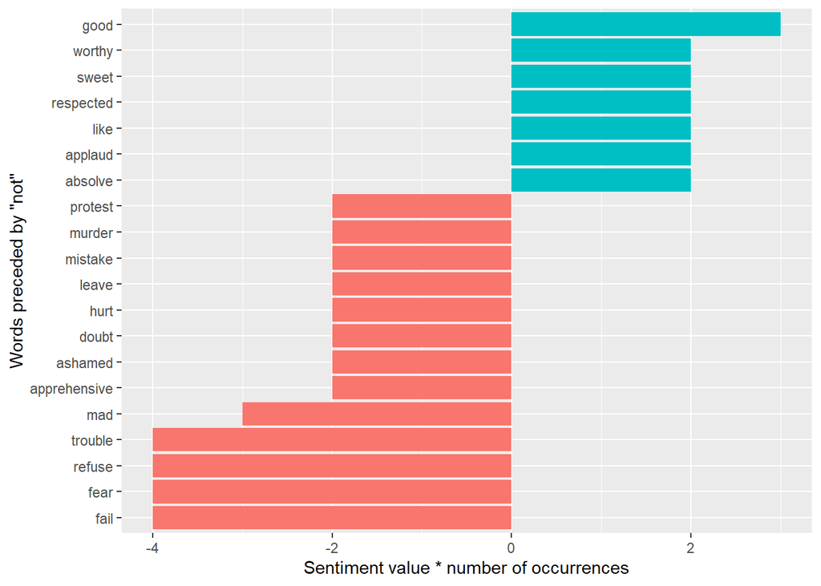

```r
not_words %>%
  mutate(contribution = n * value) %>%
  arrange(desc(abs(contribution))) %>%
  head(20) %>%
  mutate(word2 = reorder(word2, contribution)) %>%
  ggplot(aes(n * value, word2, fill = n * value > 0)) +
  geom_col(show.legend = FALSE) +
  labs(x = "Sentiment value * number of occurrences",
       y = "Words preceded by \"not\"")
```

“iyi olmamak” bigramı yanlış tanımlamalara sebep oldu.Çünkü “iyi” kelimesi pozitif bir kelime olduğundan “not” yanında yer alarak eserin olumlu sonuçlar vermesine katkı sağladı. Sonuç olarak bu dört olumsuzlamanın yanında olan her kelime analiz sonuçlarımızı yanlış bir şekilde etkiledi.

```r
negation_words <- c("not", "no", "never", "without")

negated_words <- bigrams_separated %>%
  filter(word1 %in% negation_words) %>%
  inner_join(AFINN, by = c(word2 = "word")) %>%
  count(word1, word2, value, sort = TRUE)
negated_words
```

```
## # A tibble: 51 x 4
##    word1 word2   value     n
##    <chr> <chr>   <dbl> <int>
##  1 no    faith       1     4
##  2 no    no         -1     4
##  3 no    comfort     2     2
##  4 no    matter      1     2
##  5 no    noble       2     2
##  6 not   doubt      -1     2
##  7 not   fail       -2     2
##  8 not   fear       -2     2
##  9 not   leave      -1     2
## 10 not   refuse     -2     2
## # ... with 41 more rows
```

“not” bir sonraki terimi olumsuzlaştıran tek bağlam değildir. No,never,without ile de yandaki terimleri olumsuzlaştırmak mümkündür.Bu tabloda, özünde olumlu olup aslında olumsuz olan ve yanlış analiz sonuçlar alınmasına sebep olan tüm kelimeleri görmekteyiz.

```r
bigram_graph <- bigram_counts %>%
  filter(n >3) %>%
  graph_from_data_frame()
bigram_graph
```

```
## IGRAPH 3c67600 DN-- 79 62 --
## + attr: name (v/c), n (e/n)
## + edges from 3c67600 (vertex names):
##  [1] NA      ->NA        sir     ->john      sir     ->amorous
##  [4] sir     ->dauphine  john    ->daw       ben     ->jonson
##  [7] master  ->truewit   jack    ->daw       true    ->nay
## [10] master  ->doctor    master  ->parson    coin    ->worth
## [13] cler    ->nay       enter   ->truewıt   lady    ->haughty
## [16] mute    ->makes     king    ->james     master  ->clerimont
## [19] mistress->otter     mıstress->otter     daw     ->nay
## [22] gold    ->coin      enter   ->morose    fencing ->term
## + ... omitted several edges
```

Tabloda en yaygın ikilemeleri yani bigramları görmekteyiz.Buradan; Otter karakterinin bir kaptan olduğunu,olayın geçtiği evin Morose karakterine ait olduğunu,olayın ev dışında Bartholomew adında bir fuarda da geçtiğini söyleyebiliriz. Ayrıca Cynthia’s revels ikilemesinden bir eğlence olduğunu ve silent woman ikileminden ise sessiz bir kadın olduğunu görüyoruz. Önceki yorumlarımızda “no” olumsuzlaştırmasının yanında gürültü kelimesini görmüştük.Bu eğlencenin bir gürültüye sebep olduğunu ve yine önceki analiz sonuçlarımıza göre bir boşanmaya sebebiyet verebileceği varsayımında bulunabiliriz.Hatırlarsak house kelimesini filtrelediğimizde ilk sırada Morose karakterini görmüştük. Tüm sonuçları birleştirdiğimizde bu evliliğin Morose karakterine ait olduğunu da düşünebiliriz.

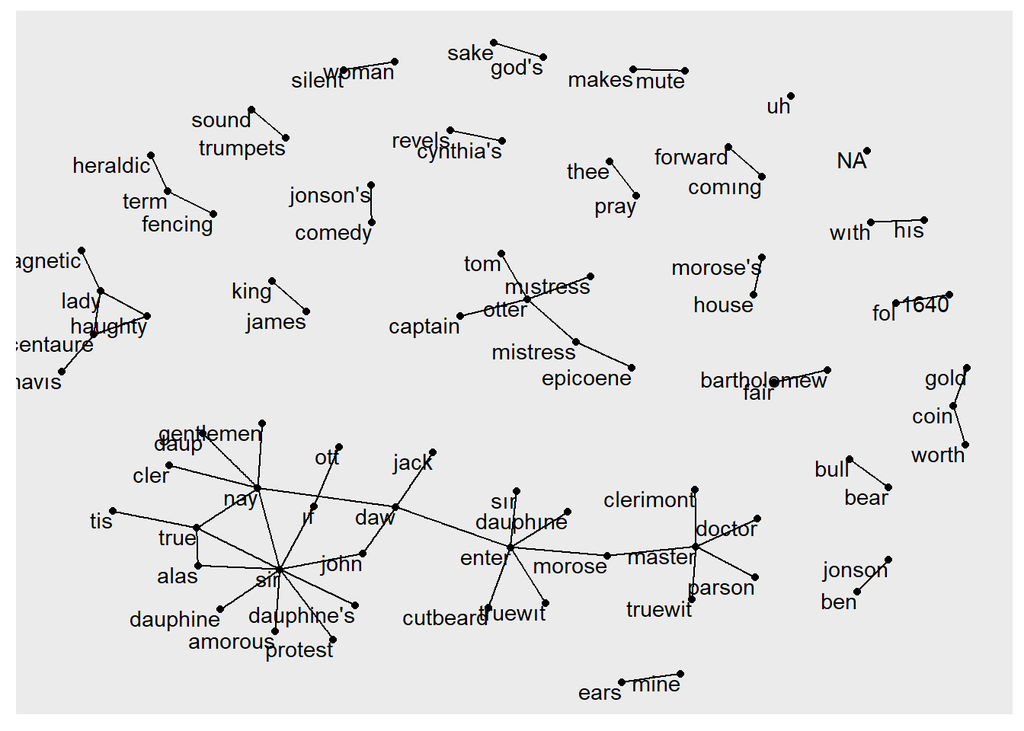

```r
set.seed(2019)

ggraph(bigram_graph, layout = "fr") +
  geom_edge_link() +
  geom_node_point() +
  geom_node_text(aes(label = name), vjust = 1, hjust = 1)
```

Olaylar arasındaki ilişkileri bu ağ görselleştirmesiyle de görebiliriz.

```r
epicoene_section_words <- epicoene %>%
  mutate(section = row_number() %/% 10) %>%
  filter(section > 0) %>%
  unnest_tokens(word, text) %>%
  filter(!word %in% stop_words$word)

epicoene_section_words
```

```
## # A tibble: 23,338 x 4
##    gutenberg_id title                          section word
##           <int> <chr>                            <dbl> <chr>
##  1         4011 Epicoene; Or, The Silent Woman       1 ıntroductıon
##  2         4011 Epicoene; Or, The Silent Woman       1 english
##  3         4011 Epicoene; Or, The Silent Woman       1 dramatists
##  4         4011 Epicoene; Or, The Silent Woman       1 shakespeare
##  5         4011 Epicoene; Or, The Silent Woman       1 literary
##  6         4011 Epicoene; Or, The Silent Woman       1 dictator
##  7         4011 Epicoene; Or, The Silent Woman       1 poet
##  8         4011 Epicoene; Or, The Silent Woman       1 laureate
##  9         4011 Epicoene; Or, The Silent Woman       1 writer
## 10         4011 Epicoene; Or, The Silent Woman       1 verse
## # ... with 23,328 more rows
```

Burada eseri 10ar satırlık bölümlere ayırdık ve hangi kelimelerin görünme eğiliminde olduğunu analiz ettik.

```r
library(widyr)
word_pairs <- epicoene_section_words %>%
  anti_join(mystopwords) %>%
  pairwise_count(word, section, sort = TRUE)
word_pairs
```

```
## # A tibble: 438,602 x 3
##    item1 item2     n
##    <chr> <chr> <dbl>
##  1 sir   true    115
##  2 true  sir     115
##  3 daw   sir      82
##  4 sir   daw      82
##  5 mor   sir      79
##  6 sir   mor      79
##  7 cler  true     78
##  8 cler  sir      78
##  9 true  cler     78
## 10 sir   cler     78
## # ... with 438,592 more rows
```

Widyr paketinin yararlı bir işlevi olan pairwise_count() fonksiyonu bize aynı bölümlerde ilişkili 2li kelimeleri, kullanılma sıklığına göre görüntüleme olanağı sağlar.Tablodan da karakterler arası diyalogların sıklık sayılarını görebiliriz.

```r
word_pairs %>%
  filter(item1 == "morose")
```

```
## # A tibble: 363 x 3
##    item1  item2      n
##    <chr>  <chr>  <dbl>
##  1 morose sir       11
##  2 morose hau       11
##  3 morose mor       10
##  4 morose true       9
##  5 morose epı        9
##  6 morose enter      8
##  7 morose madam      8
##  8 morose master     7
##  9 morose wıth       6
## 10 morose cen        6
## # ... with 353 more rows
```

2li kelimelerden Morose karakterini filtrelediğimizde bu karakterin en çok ilişkili olduğu karakterleri görmemiz mümkündür.

```r
word_cors <- epicoene_section_words %>%
  group_by(word) %>%
  filter(n() >= 20) %>%
  pairwise_cor(word, section, sort = TRUE)

word_cors
```

```
## # A tibble: 11,772 x 3
##    item1 item2 correlation
##    <chr> <chr>       <dbl>
##  1 cen   hau         0.604
##  2 hau   cen         0.604
##  3 hau   madam       0.581
##  4 madam hau         0.581
##  5 foole la          0.554
##  6 la    foole       0.554
##  7 coin  worth       0.512
##  8 worth coin        0.512
##  9 thee  thou        0.490
## 10 thou  thee        0.490
## # ... with 11,762 more rows
```

pairwise_cor fonksiyonu, bize ikili korelasyon için ortak bir ölçü olan phi katsayısını verir.Phi katsayısı, ikili verilere uygulandığında, Pearson korelasyonuna eşdeğerdir. Korelasyon katsayıları arttıkça ikili karakter ilişkilerini sık bir şekilde görüyoruz.Buradan da eserde diyalogların sık olduğunu anlamamız mümkündür.

```r
word_cors %>%
  filter(item1 == "epı")
```

```
## # A tibble: 108 x 3
##    item1 item2    correlation
##    <chr> <chr>          <dbl>
##  1 epı   mor            0.305
##  2 epı   morose         0.217
##  3 epı   servant        0.202
##  4 epı   hau            0.185
##  5 epı   mistress       0.167
##  6 epı   ı              0.161
##  7 epı   pray           0.159
##  8 epı   lady           0.146
##  9 epı   cutbeard       0.134
## 10 epı   ladies         0.126
## # ... with 98 more rows
```

Epicoene karakterinin bigramlarında çıkan korelasyon değerine bakacak olursak korelasyon değerlerinin küçük olduğunu fakat ilk iki sırada Morose karakterinin yer aldığını görüyoruz.Önceki analizlerde Morose karakterinin bir evlilik geçirdiği varsayımından bahsetmiştik. Aynı analizde sessiz bir kadın profiliyle de karsılaşmıştık. Bu tabloya baktığımızda Morose karakterinin evlendiği ve sessiz bir yapıda olan bu kadının Epicoene karakteri olabileceği kanısına varabiliriz.

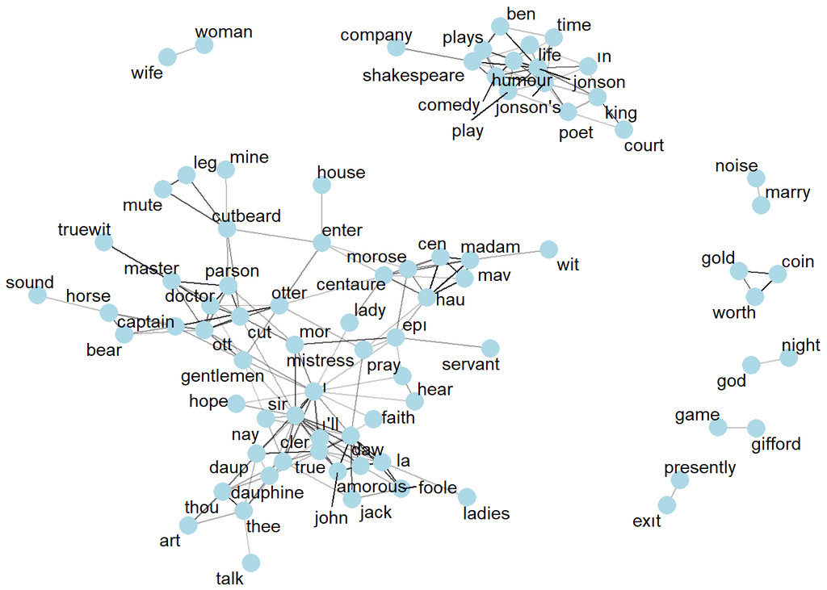

```r
set.seed(2016)

word_cors %>%
  filter(correlation > .15) %>%
  graph_from_data_frame() %>%
  ggraph(layout = "fr") +
  geom_edge_link(aes(edge_alpha = correlation), show.legend = FALSE) +
  geom_node_point(color = "lightblue", size = 5) +
  geom_node_text(aes(label = name), repel = TRUE) +
  theme_void()
```